# Ville T. Aro

# 2.3 Now we fit the model

```r
malli <- lm(points ~ attitude + stra + surf, data=learning2014)
summary(malli)
```

```
##
## Call:
## lm(formula = points ~ attitude + stra + surf, data = learning2014)
##
## Residuals:
##      Min       1Q   Median       3Q      Max
## -17.1550  -3.4346   0.5156   3.6401  10.8952
##
## Coefficients:
##             Estimate Std. Error t value Pr(>|t|)
## (Intercept)  11.0171     3.6837   2.991  0.00322 **
## attitude      3.3952     0.5741   5.913 1.93e-08 ***
## stra          0.8531     0.5416   1.575  0.11716
## surf         -0.5861     0.8014  -0.731  0.46563
## ---
## Signif. codes:  0 '***' 0.001 '**' 0.01 '*' 0.05 '.' 0.1 ' ' 1
##
## Residual standard error: 5.296 on 162 degrees of freedom
## Multiple R-squared:  0.2074, Adjusted R-squared:  0.1927
## F-statistic: 14.13 on 3 and 162 DF,  p-value: 3.156e-08
```

The only variable with enough significance in p-value is attitude. This is the reason why we remove stra and surf variables from the model. Now we fit it again.

```r
malli <- lm(points ~ attitude, data=learning2014)
summary(malli)
```

```
##
## Call:
## lm(formula = points ~ attitude, data = learning2014)
##
## Residuals:
##      Min       1Q   Median       3Q      Max
## -16.9763  -3.2119   0.4339   4.1534  10.6645
##
## Coefficients:
##             Estimate Std. Error t value Pr(>|t|)
## (Intercept)  11.6372     1.8303   6.358 1.95e-09 ***
## attitude      3.5255     0.5674   6.214 4.12e-09 ***
## ---
## Signif. codes:  0 '***' 0.001 '**' 0.01 '*' 0.05 '.' 0.1 ' ' 1
##
## Residual standard error: 5.32 on 164 degrees of freedom
## Multiple R-squared:  0.1906, Adjusted R-squared:  0.1856
## F-statistic: 38.61 on 1 and 164 DF,  p-value: 4.119e-09
```

The multiple R-squared refers to the usual R^2. R^2 can be interpreted as the fraction of the variance of the result variable that is explained by the explanatory variables. In the model R^2 is 0.1906 which is quite low so one could say that it doesn’t explain the result variable too well.

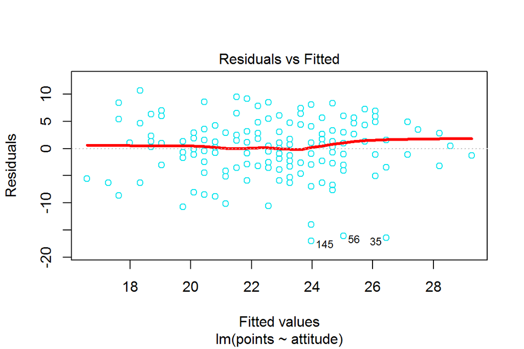

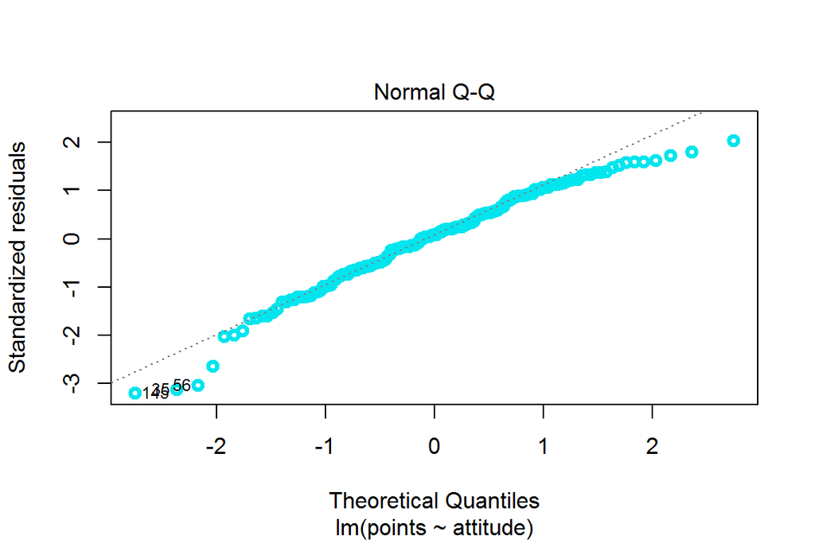

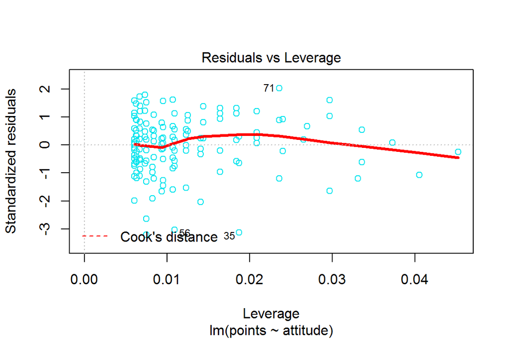

```r
library(ggplot2)
plot(malli, which=c(1, 2,5), col = "turquoise2",  lwd = 3)
```

“Residuals vs Fitted”-plot shows whether the residuals have non-linear patterns. Comparing this picture with the models first three assumptions we seem to have a few outliers. Otherwise everything looks good.

“Normal Q-Q”-plot shows whether the residuals are normally distributed. This means we can see how well the theoretical residuals correspond to the actual ones.

“Residuals vs Leverage” helps us to look for the outliers.

# Chapter 3: Logistic regression

```r
library(dplyr)
alc <- read.table("http://s3.amazonaws.com/assets.datacamp.com/production/course_2218/datasets/alc.txt ", header=T, sep=",")

dim(alc)
```

```
## [1] 382  35
```

```r
colnames(alc)
```

```
##  [1] "school"     "sex"        "age"        "address"    "famsize"
##  [6] "Pstatus"    "Medu"       "Fedu"       "Mjob"       "Fjob"
## [11] "reason"     "nursery"    "internet"   "guardian"   "traveltime"
## [16] "studytime"  "failures"   "schoolsup"  "famsup"     "paid"
## [21] "activities" "higher"     "romantic"   "famrel"     "freetime"
## [26] "goout"      "Dalc"       "Walc"       "health"     "absences"
## [31] "G1"         "G2"         "G3"         "alc_use"    "high_use"
```

The data has 382 observations and 35 variables after we did the following changes: - The variables not used for joining the two data have been combined by averaging (including the grade variables) - ‘alc_use’ is the average of ‘Dalc’ and ‘Walc’ - ‘high_use’ is TRUE if ‘alc_use’ is higher than 2 and FALSE otherwise

The data is about students alcohol consumption.

I’m going to conduct an analysis on relationships between high/low alcohol consumption and sex, age and the grades G1, G2 and G3.

My hypothesis were as follows:

H1: Lower grades lead to higher alcohol consumption. H2: Male students drink more than female students. H3: The age variable doesn’t have a lot of effect.

Drawing the plots and figuring out how my hypotheses begins to look.

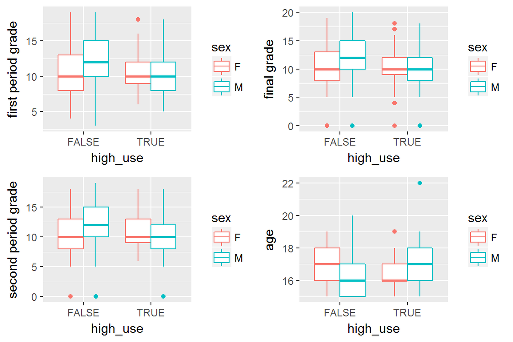

```r
library(ggplot2)
p1 <- ggplot(alc, aes(x = high_use, y = G1, col = sex)) + geom_boxplot() + ylab("first period grade")

p2 <- ggplot(alc, aes(x = high_use, y = G2, col = sex)) + geom_boxplot() + ylab("second period grade")

p3 <- ggplot(alc, aes(x = high_use, y = G3, col = sex)) + geom_boxplot() + ylab("final grade")

p4 <- ggplot(alc, aes(x = high_use, y = age, col = sex)) + geom_boxplot() + ylab("age")

multiplot(p1, p2, p3, p4, cols = 2)
```

We begin from the top left corner. The grades go from 0 to 20 and alcohol usage has a binary (0,1) value. The binary values is presented in false and high. There we see that first period grades are a little bit better when high alcohol usage gets the false value. we also see that the tails are long which means also higher outliers in the model.

The second picture in the left bottom corner tells quite the same story as the picture above but now y-scale is second period grade. Quite interesting is that the tails in the lower end of grade scale are high as there a dots in the grade = 0. That means outliers again.

The third picture in the top right corner has final grade and alcohol consumption. We don’t really see any large changes so let’s move on.

The fouth and final picture in the bottom right corner is very interesting. First of all we see that the age is quite low in the high alcohol usage for example compared to Finland. The mean value in female group is 16 and 17 in the male group. That is why it is also smart to look at the age factor in the whole data. It looks like this:

```r
summary(alc$age)
```

```
##    Min. 1st Qu.  Median    Mean 3rd Qu.    Max.
##   15.00   16.00   17.00   16.59   17.00   22.00
```

Now lets make a model based on the hypotheses above. I’m trying to explain high usage of alcohol with grades, sex and age. I’m using logistic regression model below.

```r
model2 <- glm(high_use ~ G1 + G2 + G3 + sex + age, family = "binomial", data = alc)

summary(model2)
```

```
##
## Call:
## glm(formula = high_use ~ G1 + G2 + G3 + sex + age, family = "binomial",
##     data = alc)
##
## Deviance Residuals:
##     Min       1Q   Median       3Q      Max
## -1.5220  -0.8417  -0.6686   1.1570   2.1413
##
## Coefficients:
##              Estimate Std. Error z value Pr(>|z|)
## (Intercept) -3.895489   1.807142  -2.156   0.0311 *
## G1          -0.178473   0.073996  -2.412   0.0159 *
## G2           0.004475   0.088770   0.050   0.9598
## G3           0.081996   0.061465   1.334   0.1822
## sexM         0.962330   0.239154   4.024 5.72e-05 ***
## age          0.212090   0.103040   2.058   0.0396 *
## ---
## Signif. codes:  0 '***' 0.001 '**' 0.01 '*' 0.05 '.' 0.1 ' ' 1
##
## (Dispersion parameter for binomial family taken to be 1)
##
##     Null deviance: 462.21  on 381  degrees of freedom
## Residual deviance: 433.69  on 376  degrees of freedom
## AIC: 445.69
##
## Number of Fisher Scoring iterations: 4
```

Now we calculate odd raiots and their CIs.

```r
OR <- coef(model2) %>% exp
CI <- confint(model2) %>% exp
cbind(OR,CI)
```

```
##                     OR        2.5 %    97.5 %
## (Intercept) 0.02033343 0.0005560289 0.6762128
## G1          0.83654645 0.7201998351 0.9632938
## G2          1.00448490 0.8433762954 1.1972492
## G3          1.08545156 0.9673539597 1.2340260
## sexM        2.61778817 1.6469686500 4.2128194
## age         1.23625854 1.0123920001 1.5178536
```

```r
model3 <- glm(high_use ~ G1 + sex, family = "binomial", data = alc)

summary(model3)
```

```
##
## Call:
## glm(formula = high_use ~ G1 + sex, family = "binomial", data = alc)
##
## Deviance Residuals:
##     Min       1Q   Median       3Q      Max
## -1.3037  -0.8390  -0.6862   1.2508   2.0911
##
## Coefficients:
##             Estimate Std. Error z value Pr(>|z|)
## (Intercept) -0.39990    0.39690  -1.008  0.31368
## G1          -0.09263    0.03590  -2.580  0.00987 **
## sexM         0.96992    0.23735   4.086 4.38e-05 ***
## ---
## Signif. codes:  0 '***' 0.001 '**' 0.01 '*' 0.05 '.' 0.1 ' ' 1
##
## (Dispersion parameter for binomial family taken to be 1)
##
##     Null deviance: 462.21  on 381  degrees of freedom
## Residual deviance: 440.48  on 379  degrees of freedom
## AIC: 446.48
##
## Number of Fisher Scoring iterations: 4
```

The result completely different now than compared to the first and G1 got the second *. It is looking a lot more significant now.

Also the intercept rose from -3.895489 to -0.39990 which is a huge change.

```r
OR <- coef(model3) %>% exp
CI <- confint(model3) %>% exp
cbind(OR,CI)
```

```
##                    OR     2.5 %   97.5 %
## (Intercept) 0.6703900 0.3065190 1.457539
## G1          0.9115336 0.8484642 0.976978
## sexM        2.6377259 1.6654805 4.230000
```

Second look at the odds ratios which look quite the same as the first time. Sex still has the highest prediction power.

```r
probabilities <- predict(model3, type = "response")

alc <- mutate(alc, probability = probabilities)


alc <- mutate(alc, prediction = probabilities > 0.5)

table(high_use = alc$high_use, prediction = alc$prediction) %>% prop.table %>% addmargins
```

```
##         prediction
## high_use      FALSE       TRUE        Sum
##    FALSE 0.69109948 0.01570681 0.70680628
##    TRUE  0.26439791 0.02879581 0.29319372
##    Sum   0.95549738 0.04450262 1.00000000
```

Then I calculated the penalty/loss rate and this tells how many times the model classified observations incorrectly. The average number of incorrect predictions was 0.2801047.

```r
loss_func <- function(class, prob) {
  n_wrong <- abs(class - prob) > 0.5
  mean(n_wrong)
}

loss_func(class = alc$high_use, prob = alc$probability)
```

```
## [1] 0.2801047
```

The last step was to cross validate my model against randomly allocated parts of the alc data. I used a 10-fold cross-validation. The average amount of wrong preditions is around 30 which is higher than the one I got above

```r
library(boot)
# K-fold cross-validation
cv <- cv.glm(data = alc, cost = loss_func, glmfit = model3, K = 10)

# average number of wrong answers
cv$delta[1]
```

```
## [1] 0.3036649
```

# Chapter 4: Clustering and stuff’

We begin this week by analysing data from R’s MASS package. The data contains information about The Boston area house-prices.

```r
data("Boston")

str(Boston)
```

```
## 'data.frame':    506 obs. of  14 variables:
##  $ crim   : num  0.00632 0.02731 0.02729 0.03237 0.06905 ...
##  $ zn     : num  18 0 0 0 0 0 12.5 12.5 12.5 12.5 ...
##  $ indus  : num  2.31 7.07 7.07 2.18 2.18 2.18 7.87 7.87 7.87 7.87 ...
##  $ chas   : int  0 0 0 0 0 0 0 0 0 0 ...
##  $ nox    : num  0.538 0.469 0.469 0.458 0.458 0.458 0.524 0.524 0.524 0.524 ...
##  $ rm     : num  6.58 6.42 7.18 7 7.15 ...
##  $ age    : num  65.2 78.9 61.1 45.8 54.2 58.7 66.6 96.1 100 85.9 ...
##  $ dis    : num  4.09 4.97 4.97 6.06 6.06 ...
##  $ rad    : int  1 2 2 3 3 3 5 5 5 5 ...
##  $ tax    : num  296 242 242 222 222 222 311 311 311 311 ...
##  $ ptratio: num  15.3 17.8 17.8 18.7 18.7 18.7 15.2 15.2 15.2 15.2 ...
##  $ black  : num  397 397 393 395 397 ...
##  $ lstat  : num  4.98 9.14 4.03 2.94 5.33 ...
##  $ medv   : num  24 21.6 34.7 33.4 36.2 28.7 22.9 27.1 16.5 18.9 ...
```

```r
dim(Boston)
```

```
## [1] 506  14
```

The data has 506 observations and 14 different variables. Next we plot the data to show the graphical overview and then we check how different variables compare to each other.

```r
summary(Boston)
```

```
##       crim                zn             indus            chas
##  Min.   : 0.00632   Min.   :  0.00   Min.   : 0.46   Min.   :0.00000
##  1st Qu.: 0.08204   1st Qu.:  0.00   1st Qu.: 5.19   1st Qu.:0.00000
##  Median : 0.25651   Median :  0.00   Median : 9.69   Median :0.00000
##  Mean   : 3.61352   Mean   : 11.36   Mean   :11.14   Mean   :0.06917
##  3rd Qu.: 3.67708   3rd Qu.: 12.50   3rd Qu.:18.10   3rd Qu.:0.00000
##  Max.   :88.97620   Max.   :100.00   Max.   :27.74   Max.   :1.00000
##       nox               rm             age              dis
##  Min.   :0.3850   Min.   :3.561   Min.   :  2.90   Min.   : 1.130
##  1st Qu.:0.4490   1st Qu.:5.886   1st Qu.: 45.02   1st Qu.: 2.100
##  Median :0.5380   Median :6.208   Median : 77.50   Median : 3.207
##  Mean   :0.5547   Mean   :6.285   Mean   : 68.57   Mean   : 3.795
##  3rd Qu.:0.6240   3rd Qu.:6.623   3rd Qu.: 94.08   3rd Qu.: 5.188
##  Max.   :0.8710   Max.   :8.780   Max.   :100.00   Max.   :12.127
##       rad              tax           ptratio          black
##  Min.   : 1.000   Min.   :187.0   Min.   :12.60   Min.   :  0.32
##  1st Qu.: 4.000   1st Qu.:279.0   1st Qu.:17.40   1st Qu.:375.38
##  Median : 5.000   Median :330.0   Median :19.05   Median :391.44
##  Mean   : 9.549   Mean   :408.2   Mean   :18.46   Mean   :356.67
##  3rd Qu.:24.000   3rd Qu.:666.0   3rd Qu.:20.20   3rd Qu.:396.23
##  Max.   :24.000   Max.   :711.0   Max.   :22.00   Max.   :396.90
##      lstat            medv
##  Min.   : 1.73   Min.   : 5.00
##  1st Qu.: 6.95   1st Qu.:17.02
##  Median :11.36   Median :21.20
##  Mean   :12.65   Mean   :22.53
##  3rd Qu.:16.95   3rd Qu.:25.00
##  Max.   :37.97   Max.   :50.00
```

This week we focus on the crim variable.

```r
cor_matrix<-cor(Boston)


cor_matrix %>% round(digits = 2)
```

```
##          crim    zn indus  chas   nox    rm   age   dis   rad   tax
## crim     1.00 -0.20  0.41 -0.06  0.42 -0.22  0.35 -0.38  0.63  0.58
## zn      -0.20  1.00 -0.53 -0.04 -0.52  0.31 -0.57  0.66 -0.31 -0.31
## indus    0.41 -0.53  1.00  0.06  0.76 -0.39  0.64 -0.71  0.60  0.72
## chas    -0.06 -0.04  0.06  1.00  0.09  0.09  0.09 -0.10 -0.01 -0.04
## nox      0.42 -0.52  0.76  0.09  1.00 -0.30  0.73 -0.77  0.61  0.67
## rm      -0.22  0.31 -0.39  0.09 -0.30  1.00 -0.24  0.21 -0.21 -0.29
## age      0.35 -0.57  0.64  0.09  0.73 -0.24  1.00 -0.75  0.46  0.51
## dis     -0.38  0.66 -0.71 -0.10 -0.77  0.21 -0.75  1.00 -0.49 -0.53
## rad      0.63 -0.31  0.60 -0.01  0.61 -0.21  0.46 -0.49  1.00  0.91
## tax      0.58 -0.31  0.72 -0.04  0.67 -0.29  0.51 -0.53  0.91  1.00
## ptratio  0.29 -0.39  0.38 -0.12  0.19 -0.36  0.26 -0.23  0.46  0.46
## black   -0.39  0.18 -0.36  0.05 -0.38  0.13 -0.27  0.29 -0.44 -0.44
## lstat    0.46 -0.41  0.60 -0.05  0.59 -0.61  0.60 -0.50  0.49  0.54
## medv    -0.39  0.36 -0.48  0.18 -0.43  0.70 -0.38  0.25 -0.38 -0.47
##         ptratio black lstat  medv
## crim       0.29 -0.39  0.46 -0.39
## zn        -0.39  0.18 -0.41  0.36
## indus      0.38 -0.36  0.60 -0.48
## chas      -0.12  0.05 -0.05  0.18
## nox        0.19 -0.38  0.59 -0.43
## rm        -0.36  0.13 -0.61  0.70
## age        0.26 -0.27  0.60 -0.38
## dis       -0.23  0.29 -0.50  0.25
## rad        0.46 -0.44  0.49 -0.38
## tax        0.46 -0.44  0.54 -0.47
## ptratio    1.00 -0.18  0.37 -0.51
## black     -0.18  1.00 -0.37  0.33
## lstat      0.37 -0.37  1.00 -0.74
## medv      -0.51  0.33 -0.74  1.00
```

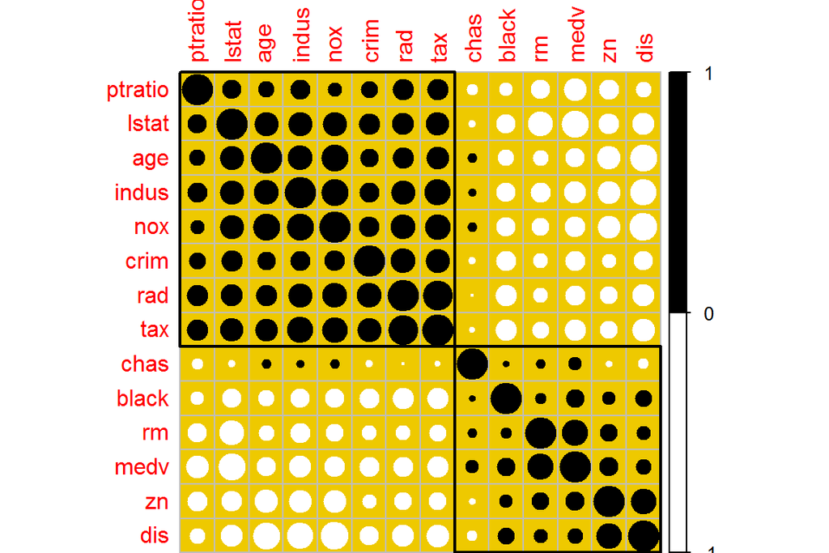

```r
wb <- c("white","black")

corrplot(cor_matrix, order="hclust", addrect=2, bg="gold2", col=wb)
```

This is a correlation plot which explain the correlations of different variables when being compared to each other. The bigger the spot the stronger the correlation.

One of the biggest one in the positive side is rad - tax. From the negative correlation side the biggest ones are dis - indus, dis - nox and dis - age.